# Practical Machine Learning - Writeup

Shawn Tan

Sunday, Mar 22, 2015

# Background

Using devices such as Jawbone Up, Nike FuelBand, and Fitbit it is now possible to collect a large amount of data about personal activity relatively inexpensively. These type of devices are part of the quantified self movement - a group of enthusiasts who take measurements about themselves regularly to improve their health, to find patterns in their behavior, or because they are tech geeks. One thing that people regularly do is quantify how much of a particular activity they do, but they rarely quantify how well they do it. In this project, your goal will be to use data from accelerometers on the belt, forearm, arm, and dumbell of 6 participants. They were asked to perform barbell lifts correctly and incorrectly in 5 different ways. More information is available from the website here: http://groupware.les.inf.puc-rio.br/har (see the section on the Weight Lifting Exercise Dataset).

# Data source

The training and test data for this project come from this source: http://groupware.les.inf.puc-rio.br/har.

# Assignment

The goal of your project is to predict the manner in which they did the exercise. This is the “classe” variable in the training set. You may use any of the other variables to predict with. You should create a report describing 1) how you built your model 2) how you used cross validation, 3) what you think the expected out of sample error is 4) why you made the choices you did. 5) use your prediction model to predict 20 different test cases.

1. Your submission should consist of a link to a Github repo with your R markdown and compiled HTML file describing your analysis. Please constrain the text of the writeup to < 2000 words and the number of figures to be less than 5. It will make it easier for the graders if you submit a repo with a gh-pages branch so the HTML page can be viewed online (and you always want to make it easy on graders :-).
2. You should also apply your machine learning algorithm to the 20 test cases available in the test data above. Please submit your predictions in appropriate format to the programming assignment for automated grading. See the programming assignment for additional details.

## Data processing

We first begin by loading, cleaning and splitting the data accordingly.

```r
train<-read.csv("pml-training.csv",na.strings=c("NA","")) #load training set
library(randomForest)
library(caret)
library(doParallel)
set.seed(123654) #setting the seed for reproducibility
```

The data was cleaned up by removing NA values, near-zero variance predictors and irrelevant columns not useful for prediction (columns 1 to 7). Upon processing, the training dataset had 160 columns/variables reduced to 52.

```r
traindata <- train[, which(as.numeric(colSums(is.na(train)))==0)]
nearZeroCol <- nearZeroVar(traindata, saveMetrics = TRUE)
traindata <- traindata[, nearZeroCol$nzv==FALSE]
traindata <- traindata[,-(1:7)]
```

The training set data was split into two sets - 60% for training and 40% for validation.

```r
trainset <- createDataPartition(traindata$classe, p = 0.6, list = FALSE)
trainP <- traindata[trainset,]
validateP <- traindata[-trainset,]
```

## Building the Model

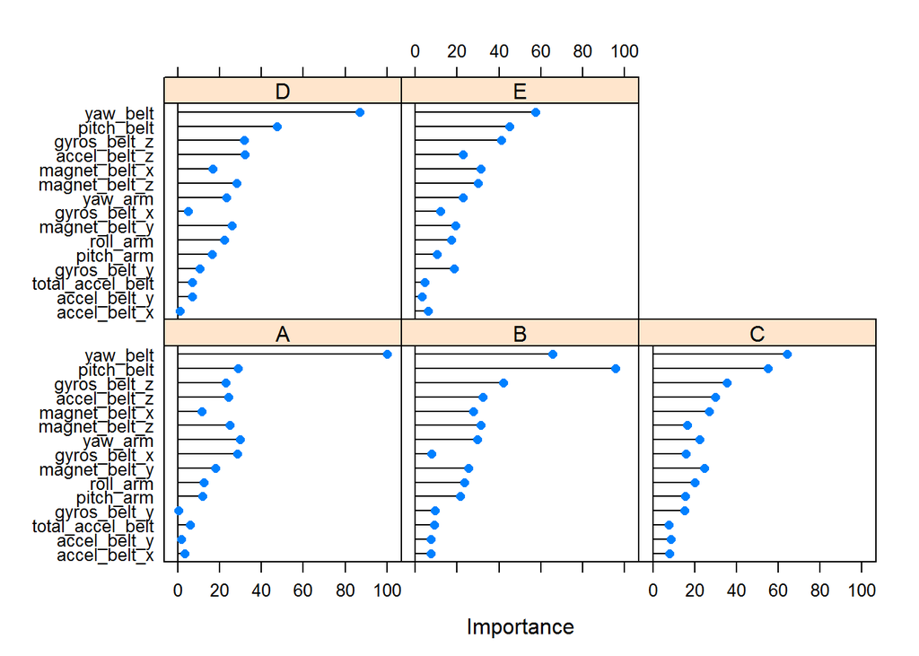

```r
registerDoParallel(makeCluster(detectCores()))
sampletrainCtrl <- trainControl(method = "oob")
model_rf <- train(classe ~ ., method='rf', data=trainP,importance=TRUE,tuneLength=3,trControl=sampletrainCtrl)
VI<-varImp(model_rf)
VI[[1]]<-VI[[1]][1:15,]
plot(VI)
```

```r
model_rf <- train(classe ~ pitch_forearm + magnet_dumbbell_y + yaw_belt + pitch_belt + yaw_arm + gyros_belt_x
                  + accel_forearm_x + accel_dumbbell_y +  roll_arm + magnet_belt_x + gyros_belt_z + pitch_arm
                  + accel_belt_z + magnet_belt_y + magnet_belt_z,
                  method='rf', data=trainP,importance=TRUE,tuneLength=3,trControl=sampletrainCtrl)
```

## Cross-Validation

The model was tested against the partitioned set for validation (40% of the training set).

```r
model_rf$finalModel
```

```
##
## Call:
##  randomForest(x = x, y = y, mtry = param$mtry, importance = TRUE)
##                Type of random forest: classification
##                      Number of trees: 500
## No. of variables tried at each split: 2
##
##         OOB estimate of  error rate: 1.71%
## Confusion matrix:
##      A    B    C    D    E class.error
## A 3325   11    2   10    0 0.006869773
## B   34 2199   43    1    2 0.035103115
## C    0   19 2022   10    3 0.015579357
## D    1    2   35 1888    4 0.021761658
## E    0    3   13    8 2141 0.011085450
```

```r
predict_rf <- predict(model_rf, validateP)
confusionMatrix(predict_rf, validateP$classe)[3]
```

```
## $overall
##       Accuracy          Kappa  AccuracyLower  AccuracyUpper   AccuracyNull
##      0.9826663      0.9780747      0.9795288      0.9854375      0.2844762
## AccuracyPValue  McnemarPValue
##      0.0000000            NaN
```

```r
CM<-as.data.frame(confusionMatrix(predict_rf,validateP$classe)[3])
ooserror<-1-CM[1,]
ooserror
```

```
## [1] 0.01733367
```

# Prediction with testing set

```r
pml_test <-read.csv("pml-testing.csv",na.strings=c("NA","")) #load testing set
pml_predictions <- predict(model_rf,pml_test)
print(pml_predictions)
```

```
##  [1] B A B A A E D D A A B C B A E E A B B B
## Levels: A B C D E
```

## Generating submission files

```r
pml_write_files = function(x){
        n = length(x)
        for(i in 1:n){
                filename = paste0("problem_id_",i,".txt")
                write.table(x[i],file=filename,quote=FALSE,row.names=FALSE,col.names=FALSE)
        }
}
predictions<-as.vector(pml_predictions)
pml_write_files(predictions)
```